## Sonora, México Covid19 interactive Map

*Activate Sonora, Mexico, USA or World layer below, to display data accordingly*

[interactive chart not shown]

Source: Own estimation based on Dirección General de Epidemiología, oficial Mexican Government data. Data set compiled by Gabriel Alfonso Carranco-Sapiéns, Physics Institute of the National Autonomous Univesity of Mexico (UNAM).

### Northern Border States

[interactive chart not shown]

The covid19 confirmed cases path for the border states is showing a clear indication of different results of local containment measures for the spread of the virus. While, during the initial outbreak, **Nuevo León** (a state that host Monterrey, the third largest Metropolitan area in the country) had been the main focus of contagion at the border, the pattern dramatically changed by April 5th, when **Baja California** take off.

What kind of measures are working in Nuevo León, a state that appears to have **flatten the curve**, what lessons can be learned from this state´s public health control efforts. And more importantly, what factors are driving Baja California as a rapid growth area.

### The 100th cases threshold.

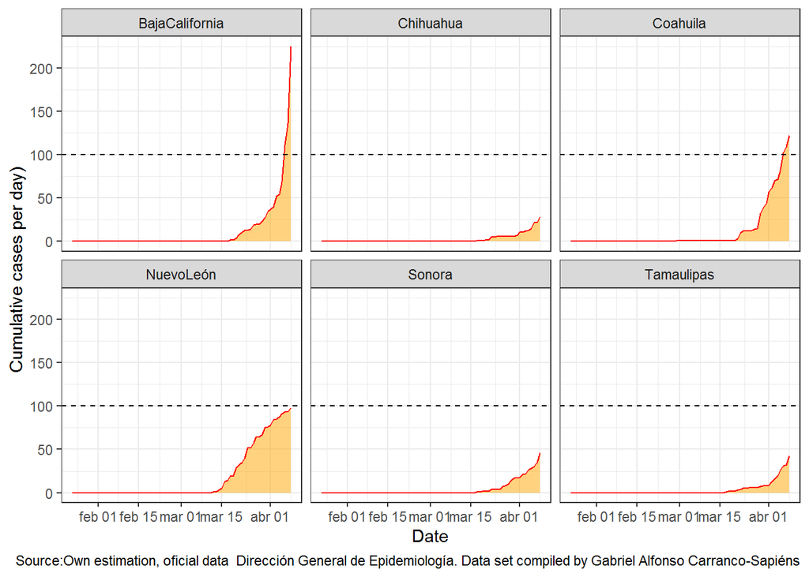

**Baja California** was the first border state to reach the **100th case threshold**, which occurred on April 06 2020.  
Two days latter, the number of cases has doubled to 225.